# MCMC (Gibbs & Metropolis-Hastings)

Justin Kao

# 🧰 Course Tools

## RStudio: Your Data Science Playground

> *I code the data, and I tell the story.*

[1. Install R](https://cran.rstudio.com/)

[2. Install Rstudio](https://posit.co/download/rstudio-desktop/)

### Markdown & Quarto: Your Storytelling Superpowers

- 🧠 **RMarkdown or Quarto:** Make sure it *knits*, *renders*, and *saves* without RStudio crying.  
  (If it knits, you’re officially a data scientist.)
- 📝 [**Markdown Basics**](https://quarto.org/docs/authoring/markdown-basics.html) — Learn how to make text bold, italic, draw diagrams, or show off anything you want to demonstrate.
- 🚀 [**Hello, Quarto**](https://quarto.org/docs/get-started/hello/rstudio.html) by Dr. Mine Çetinkaya-Rundel (Duke University) — From *“What’s a chunk?”* to *“Look, I just published my work on GitHub!”*

# Markov Chain Monte Carlo(MCMC)

## MCMC - Metropolis-Hastings Algorithm

Let’s recap of Key Concepts

- **Step 1:** Propose a candidate sample from the proposal (transition) distribution
  $$g(x_{t+1} \mid x_t)$$
  For example, if the proposal is Normal,
  $$g(x_{t+1} \mid x_t) = \mathcal{N}(x_t, \sigma^2)$$
- **Step 2:** Accept the proposed value with probability
  $$A(x_t \rightarrow x_{t+1})$$

Detail Balance Condition to reach stationary: $\quad p(a) T(a \rightarrow b)=p(b) T(b \rightarrow a), \quad \forall a, b$

$$\begin{aligned}
\frac{f(a)}{NC} g(b \mid a) A(a \rightarrow b)=\frac{f(b)}{NC } g(a \mid b) A(b \rightarrow a)
\end{aligned}$$

## MCMC - Metropolis-Hastings Algorithm

$$\begin{aligned}
\frac{f(a)}{NC} g(b \mid a) A(a \rightarrow b)=\frac{f(b)}{NC } g(a \mid b) A(b \rightarrow a)
\end{aligned}$$
Rewrite the balance condition:

$$\frac{A(a \rightarrow b)}{A(b \rightarrow a)}=\underbrace{\frac{f(b)}{f(a)}}_{r_f} \times \underbrace{\frac{g(a \mid b)}{g(b \mid a)}}_{r_g}$$

- **Scenario 1**: $r_f r_g<1, A(a \rightarrow b)=r_f r_g, A(b \rightarrow a)=1$
- **Scenario 1**: $r_f r_g>1, A(a \rightarrow b)= 1, A(b \rightarrow a)=\frac{1}{r_f r_g}$

So $A(a \rightarrow b)=\operatorname{min}\left(r_f r_g, 1\right)$

This matches the expression shown in Dr. Marina Vannucci’s slides:

$$A(\theta_{t-1} \rightarrow \theta^* = \theta_t) = \rho\left(\theta^{(t-1)}, \theta^*\right)=\min \left\{\frac{p\left(\theta^* \mid x\right)}{p\left(\theta^{(t-1)} \mid x\right)} \frac{q\left(\theta^{(t-1)} \mid \theta^*\right)}{q\left(\theta^* \mid \theta^{(t-1)}\right)}, 1\right\}$$

$$\theta^{(t)}=\left\{\begin{array}{l}
\theta^* \quad \text { with probability } \rho\left(\theta^{(t-1)}, \theta^*\right) \\
\theta^{(t-1)} \quad \text { with probability } \quad 1-\rho\left(\theta^{(t-1)}, \theta^*\right)
\end{array}\right.$$

## MCMC - Metropolis-Hastings Algorithm - Intuition

Let’s assume the distribution is symmetric

$$\frac{A(a \rightarrow b)}{A(b \rightarrow a)}=\underbrace{\frac{f(b)}{f(a)}}_{r_f} \times \underbrace{\frac{g(a \mid b)}{g(b \mid a)}}_{r_g} = \underbrace{\frac{f(b)}{f(a)}}_{r_f} = \frac{p(b)}{p(a)} = \frac{p\left(\theta^* \mid y\right)}{p\left(\theta^{(t-1)} \mid y\right)} = r$$

$A(a \rightarrow b)=\operatorname{min}\left(1, \frac{f(b)}{f(a)}\right) =\operatorname{min}\left(1, \frac{p(b)}{p(a)}\right) = \operatorname{min}\left(1, \frac{p\left(\theta^* \mid y\right)}{p\left(\theta^{(t-1)} \mid y\right)}=r\right)$

- If $r>1$:
  - Intuition: Since $\theta^{(t-1)}$ is already in our set, we should include $\theta^*$ as it has a higher probability than $\theta^{(t-1)}$.
  - Procedure: Accept $\theta^*$ into our set, i.e. set $\theta^{(s)}=\theta^*$.
- If $r<1$ :
  - Intuition: The relative frequency of $\theta$-values in our set equal to $\theta^*$ compared to those equal to $\theta^{(t-1)}$ should be $p\left(\theta^* \mid y\right) / p\left(\theta^{(t-1)} \mid y\right)=r$. This means that for every instance of $\theta^{(t-1)}$, we should have only a “fraction” of an instance of a $\theta^*$ value.
  - Procedure: Set $\theta^{(t)}$ equal to either $\theta^*$ or $\theta^{(t-1)}$, with probability $r$ and $1-r$ respectively.

## MCMC - Metropolis-Hastings Algorithm(HW problem 1)

Consider the file `school1.` dat (from the Book website) which contains data on the amount of times students at a high school spent on studying or homework during an exam period. Suppose we fit the following model:

$$\begin{aligned}
Y_i & \sim \mathcal{N}\left(\mu, \sigma^2\right), \quad i=1, \ldots, n \\
\mu & \sim \mathcal{N}\left(\mu_0, \tau_0^2\right)
\end{aligned}$$

with $\mu_0=5, \tau_0^2=0.5$. Let us fix $\sigma^2=1$. Implement a Metropolis-Hastings:

```r
library(coda)

# Read data
y <- scan(url("https://www2.stat.duke.edu/~pdh10/FCBS/Exercises/school1.dat"))
n <- length(y)

# Known hyperparameters
mu0 <- 5
tau0_sq <- 0.5
sigma_sq <- 1

# Log-posterior: log p(mu | y) ∝ log p(y | mu) + log p(mu)
log_post <- function(mu, y, mu0, tau0_sq, sigma_sq) {
  log_lik <- sum(dnorm(y, mean = mu, sd = sqrt(sigma_sq), log = TRUE))
  log_prior <- dnorm(mu, mean = mu0, sd = sqrt(tau0_sq), log = TRUE)
  log_lik + log_prior
}
```

## MCMC - Metropolis-Hastings Algorithm(HW problem 1, cont’d)

- A proposal function for $\mu$ centered at the previously sampled value.
- My proposal $\mu^* \sim q\left(\mu^* \mid \mu^{(0)}\right)=N\left(\mu^{(0)}, \sigma_p^2\right)$, where we can set $\mu^{(0)} = \bar{y}$

```r
mean(y)
```

```
[1] 9.464
```

- $\mu^*=\mu^{(t-1)}+\varepsilon, \quad \varepsilon \sim N\left(0, \sigma_p^2\right)$ Hence, $q\left(\mu^* \mid \mu^{(t-1)}\right)=N\left(\mu^{(t-1)}, \sigma_p^2\right)$

```r
# Metropolis–Hastings sampler (Random-Walk proposal)
mh_sampler <- function(sigma_p, n_iter = 5000, burn_in = 1000) {
  mu <- numeric(n_iter)
  mu[1] <- mean(y)

  for (t in 2:n_iter) {
    mu_prop <- rnorm(1, mean = mu[t - 1], sd = sigma_p)
    log_r <- log_post(mu_prop, y, mu0, tau0_sq, sigma_sq) -
             log_post(mu[t - 1], y, mu0, tau0_sq, sigma_sq)
    if (log(runif(1)) < log_r) {
      mu[t] <- mu_prop
    } else {
      mu[t] <- mu[t - 1]
    }
  }

  # Drop burn-in and return MCMC object
  chain <- mcmc(mu[(burn_in + 1):n_iter])
  return(chain)
}
```

## MCMC - Metropolis-Hastings Algorithm(HW problem 1, contd)

```r
# Run chain with sigma_p = 0.5
set.seed(425)
chain_small <- mh_sampler(sigma_p = 0.5)

# Summaries and plots
summary(chain_small)
```

```
Iterations = 1:4000
Thinning interval = 1
Number of chains = 1
Sample size per chain = 4000

1. Empirical mean and standard deviation for each variable,
   plus standard error of the mean:

          Mean             SD       Naive SE Time-series SE
      9.132470       0.193392       0.003058       0.006434

2. Quantiles for each variable:

 2.5%   25%   50%   75% 97.5%
8.768 9.002 9.133 9.264 9.505
```

## MCMC - Metropolis-Hastings Algorithm(HW problem 1, contd)

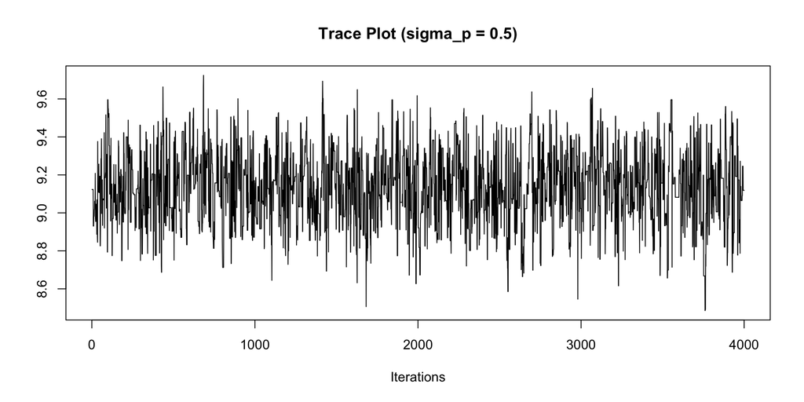

```r
traceplot(chain_small, main = "Trace Plot (sigma_p = 0.5)")
```

## MCMC - Metropolis-Hastings Algorithm(HW problem 1, contd)

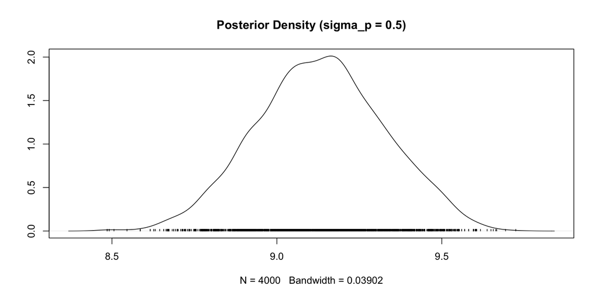

```r
densplot(chain_small, main = "Posterior Density (sigma_p = 0.5)")
```

## MCMC - Metropolis-Hastings Algorithm(HW problem 1, contd)

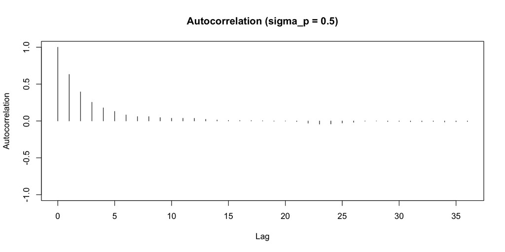

```r
autocorr.plot(chain_small, main = "Autocorrelation (sigma_p = 0.5)")
```

## MCMC - Metropolis-Hastings Algorithm(HW problem 1, contd)

(b) Provide a trace plot and a plot of the histogram and/or kernel density estimate for each chain.

> To answer this, you can run the following code and then compare the plots:

```r
set.seed(123)
chain1 <- mh_sampler(sigma_p = 0.5)
set.seed(456)
chain2 <- mh_sampler(sigma_p = 0.5)
set.seed(789)
chain3 <- mh_sampler(sigma_p = 0.5)
```

- `summary()`,`autocorr.plot()`, `densplot()`
- I have demonstrated the case when $\sigma_p=0.5$. Don’t forget to try $\sigma_p=2$ !

## MCMC - Metropolis-Hastings Algorithm(HW problem 1, cont’d)

(c) After removing an appropriate burn-in, evaluate the acceptance rate and the autocorrelation for varying lags. Which value of $\sigma_p$ provides a better choice for the proposal function?

```r
# Acceptance rate function
acceptance_rate <- function(chain) {
  draws <- as.numeric(chain)
  mean(diff(draws) != 0)
}
acceptance_rate(chain_small)
```

```
[1] 0.4211053
```

(This is just an arbitrary number I came up with — you should check your own chain.)

## MCMC - Gibbs sampler(HW problem 2)

Gibbs sampler. Consider the file `school1.` dat (from the Book) which contains data on the amount of times students at a high school spent on studying or homework during an exam period. Suppose we fit the following model:

$$\begin{aligned}
Y_i & \sim \mathcal{N}\left(\mu, \sigma^2\right), \quad i=1, \ldots, n \\
\mu & \sim \mathcal{N}\left(\mu_0, \tau_0^2\right) \\
\sigma^2 & \sim \operatorname{Inv-Gamma}(\alpha, \beta)
\end{aligned}$$

with $\mu_0=5, \tau_0^2=0.5, \alpha=1, \beta=4$.

(a) Write down the full conditionals, $p\left(\mu \mid \sigma^2, \boldsymbol{y}\right)$ and $p\left(\sigma^2 \mid \mu, \boldsymbol{y}\right)$.

$$\begin{aligned}
p\left(\mu, \sigma^2 \mid \mathbf{y}\right) & \propto p\left(\mathbf{y} \mid \mu, \sigma^2\right) p(\mu) p\left(\sigma^2\right) \\
& \propto\left(\sigma^2\right)^{-n / 2} \exp \left[-\frac{1}{2 \sigma^2} \sum\left(y_i-\mu\right)^2\right] \times \exp \left[-\frac{1}{2 \tau_0^2}\left(\mu-\mu_0\right)^2\right] \times\left(\sigma^2\right)^{-(\alpha+1)} \exp \left(-\frac{\beta}{\sigma^2}\right) \\
& \propto\left(\sigma^2\right)^{-(\alpha+n / 2+1)} \exp \left[-\frac{1}{2 \sigma^2} \sum\left(y_i-\mu\right)^2-\frac{\left(\mu-\mu_0\right)^2}{2 \tau_0^2}-\frac{\beta}{\sigma^2}\right] .
\end{aligned}$$

## MCMC - Gibbs sampler(HW problem 2, cont’d)

Say the full conditioonals are:

- $$\mu \mid \sigma^2, \mathbf{y} \sim N\left(\mu_n, \tau_n^2\right), \quad \text{where } \mu_n=\frac{\frac{n \bar{y}}{\sigma^2}+\frac{\mu_0}{\tau_0^2}}{\frac{n}{\sigma^2}+\frac{1}{\tau_0^2}}, \quad \tau_n^2=\left(\frac{n}{\sigma^2}+\frac{1}{\tau_0^2}\right)^{-1}$$
- $$\sigma^2 \mid \mu, \mathbf{y} \sim \operatorname{Inv-Gamma}\left(\alpha+\frac{n}{2}, \beta+\frac{1}{2} \sum\left(y_i-\mu\right)^2\right)$$

Let’s again setup our parameters first: $\mu_0=5, \tau_0^2=0.5, \alpha=1, \beta=4$

```r
# Parameters
mu0 <- 5
tau0_sq <- 0.5
alpha <- 1
beta <- 4

# Data
y <- scan(url("https://www2.stat.duke.edu/~pdh10/FCBS/Exercises/school1.dat"))
n <- length(y)
ybar <- mean(y)
```

## MCMC - Gibbs sampler(HW problem 2, cont’d)

```r
# Storage
n_iter <- 10000
mu <- numeric(n_iter)
sigma2 <- numeric(n_iter)

# Initial values
mu[1] <- mean(y)
sigma2[1] <- var(y)

# Gibbs sampling
for (t in 2:n_iter) {
  # 1. Sample mu | sigma2, y
  tau_n_sq <- 1 / (n / sigma2[t-1] + 1 / tau0_sq)
  mu_n <- tau_n_sq * (n * ybar / sigma2[t-1] + mu0 / tau0_sq)
  mu[t] <- rnorm(1, mu_n, sqrt(tau_n_sq))

  # 2. Sample sigma2 | mu, y
  alpha_n <- alpha + n/2
  beta_n <- beta + 0.5 * sum((y - mu[t])^2)
  sigma2[t] <- 1 / rgamma(1, shape = alpha_n, rate = beta_n)
}

# Burn-in and analysis
burn_in <- 2000
mu_samp <- mu[(burn_in + 1):n_iter]
sigma2_samp <- sigma2[(burn_in + 1):n_iter]

mu_mcmc <- mcmc(mu_samp)
sigma2_mcmc <- mcmc(sigma2_samp)
```

## MCMC - Gibbs sampler(HW problem 2, cont’d)

```r
effectiveSize(mcmc(mu_samp))
```

```
  var1
4980.3
```

```r
effectiveSize(mcmc(sigma2_samp))
```

```
    var1
5249.669
```

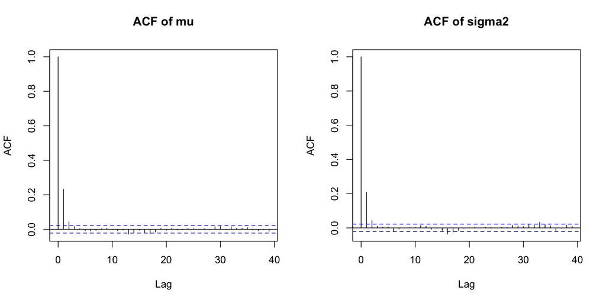

```r
par(mfrow = c(1, 2))
acf(mu_samp, main = "ACF of mu")
acf(sigma2_samp, main = "ACF of sigma2")
```

```r
par(mfrow = c(1, 1))  # reset layout
```

## MCMC - Gibbs sampler(HW problem 2, cont’d)

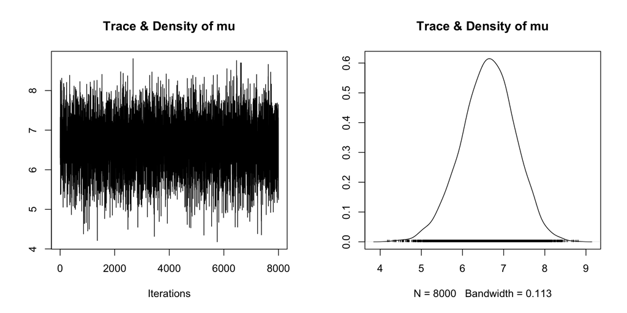

```r
plot(mu_mcmc, main = "Trace & Density of mu")
```

## MCMC - Gibbs sampler(HW problem 2, cont’d)

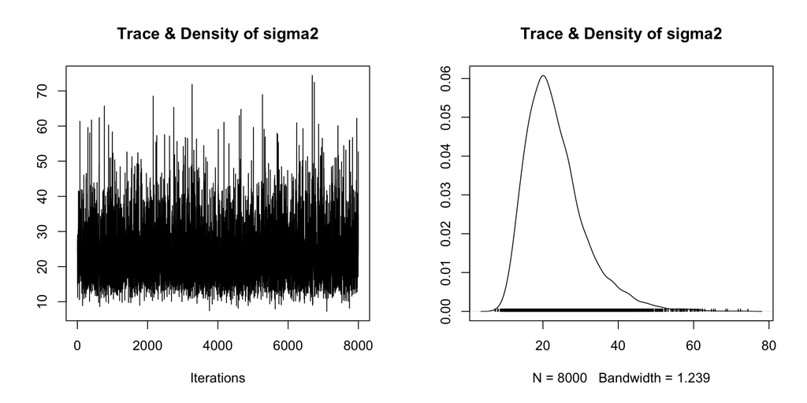

```r
plot(sigma2_mcmc, main = "Trace & Density of sigma2")
```

## MCMC - Gibbs sampler(HW problem 2, cont’d)

(d) Evaluate the marginal posterior density $p\left(\sigma^2 \mid \boldsymbol{y}\right)$ analytically up to a normalizing constant and overlay this density on your plot from (c) [Hint: you can perform the comparison by evaluating the unnormalized density on a grid of values].

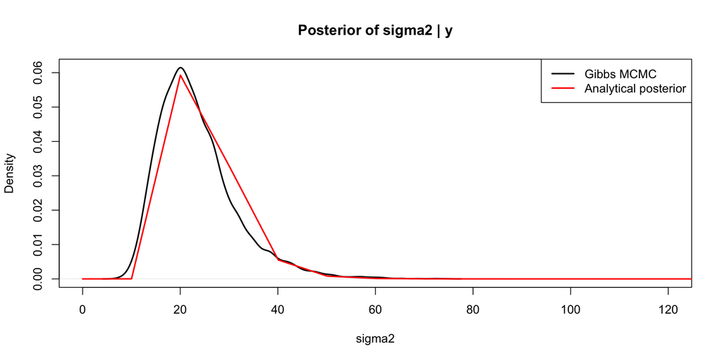

## MCMC - Gibbs sampler & MH(package(coda))

- You can technically wrap any numeric vector or matrix(`object` here) in `mcmc_obj <- mcmc(object)` , even if it isn’t a “real” MCMC sequence. However - and this is key - doing so doesn’t make it an MCMC chain in a statistical sense. It just labels it as one so that functions like `plot()`, `acf()`, and `effectiveSize()` can run without error.

| Function | Purpose |
| --- | --- |
| `effectiveSize(mcmc_obj)` | Computes **Effective Sample Size (ESS)** — measures chain independence. |
| `gelman.diag(mcmc.list_obj)` | **Gelman–Rubin diagnostic** for checking convergence across multiple chains. |
| `geweke.diag(mcmc_obj)` | **Geweke diagnostic** for within-chain convergence (compares early vs. late samples). |
| `heidel.diag(mcmc_obj)` | **Heidelberger–Welch test** for stationarity and convergence. |
| `raftery.diag(mcmc_obj)` | **Raftery–Lewis diagnostic** estimating chain length needed for precision. |

# JAGS - Just Another Gibbs Sampler

## The Posterior That Looks Easy but Isn’t — JAGS Is Your Best Friend!

Model:

$$y_i \sim \text{Cauchy}(\theta, \sigma), \quad
\theta \sim \mathcal{N}(0, 10^2), \quad
\sigma \sim \text{Uniform}(0, 10)$$

Posterior:

$$p(\theta, \sigma \mid y)
\propto
\left[ \prod_{i=1}^n
\frac{1}{\pi \sigma \left(1 + \frac{(y_i - \theta)^2}{\sigma^2}\right)} \right]
\exp\!\left(-\frac{\theta^2}{2 \times 10^2}\right)$$

It only has **two parameters**, yet the posterior is:

- ❌ No full conditional — not a known distribution
- ❌ Non-conjugate — prior and likelihood don’t simplify
- ❌ No closed-form normalization — integral can’t be solved

Result: $p(\theta,\sigma|y)$ has **no analytic form**, no direct sampler, and no closed expression.

> 🤢 Manual derivation stops here.

## What Are BUGS and JAGS?

- **BUGS (Bayesian inference Using Gibbs Sampling):**  
  Early Bayesian software (1990s, Cambridge) using Gibbs sampling. Versions include *Classic BUGS(1990s)*, *WinBUGS(Windows-only)*, and *OpenBUGS(open-source successor)*.
- **JAGS (Just Another Gibbs Sampler):**  
  Developed by Martyn Plummer in 2003 as a **cross-platform**, **open-source**, and **R-integrated** version of BUGS.

> 💡 JAGS keeps the same model syntax as BUGS but adds flexibility, automatic Metropolis–within–Gibbs sampling, and modern extensibility.

[figure not shown]

## Why JAGS

1. **Doing MCMC by hand means:**
   - Writing out **priors** and **likelihood**
   - Deriving **full conditional posteriors** for Gibbs sampling
   - Specifying a **proposal distribution** for Metropolis–Hastings
   - Tracking the **update order** for every parameter
2. As models grow complex, this becomes
   - 🔁 *tedious*,
   - 🧮 *algebraically messy*, and
   - 🚫 *often intractable.*
3. You want to spend time **analyzing**, not deriving.

> JAGS can help you solve this once you specify the prior and the likelihood!

## Enter JAGS

- **JAGS** automates MCMC sampling.
- You define your model using **BUGS-like syntax**.
- It automatically:
  - Constructs the **posterior**
  - Performs **Gibbs / Metropolis-Hastings sampling**
  - Returns results to **R** through `rjags` or `R2jags`.

## How JAGS Samples Behind the Scenes

Even within Gibbs sampling, not all parameters have closed-form conditionals.

JAGS handles this **automatically**:

| Parameter Type | Sampling Strategy | Description |
| --- | --- | --- |
| Conjugate blocks | **Pure Gibbs** | Exact draws from known conditionals |
| Non-conjugate blocks | **Metropolis–within–Gibbs** | Uses adaptive random-walk MH inside Gibbs |
| Difficult continuous nodes | **Slice sampling** | Efficient for highly nonlinear posteriors |

So Gibbs and Metropolis **run in parallel**:

- Each iteration updates some parameters by **Gibbs**, others by **Metropolis**
- JAGS adapts proposal scales automatically during burn-in
- You don’t need to code or tune anything

> 💡 *You define the model; JAGS decides the best sampler for each part.*

## How to install JAGS(Mac)

- Option 1: [Download JAGS manually](https://sourceforge.net/projects/mcmc-jags/)
- Option 2: Homebrew (Mac)

```
brew install jags #run this command in terminal
brew list --versions jags #check version
brew uninstall jags #uninstall jags
brew upgrade #upgrade
```

- If you download manually, how to remove?

```
#run this command in terminal
which jags

#if you get this, then JAGS was installed manually
/usr/local/bin/jags

# To remove it, do
sudo rm -rf /usr/local/bin/jags
sudo rm -rf /usr/local/lib/JAGS
sudo rm -rf /usr/local/share/jags
sudo rm -rf /usr/local/include/jags

# Verify JAGS is removed
which jags
```

## How to install JAGS(Windows)

1. [Download JAGS manually](https://sourceforge.net/projects/mcmc-jags/)
2. Using Command Prompt (CMD)

```
# Step 1 — Check if JAGS is installed
jags

# If JAGS is installed, you will see: Welcome to JAGS 4.3.2 (official binary)

# Type "exit" to close JAGS
exit

# Step 2 — Check the installation path (optional)
where jags

# Step 3 — To uninstall JAGS
# Go to Control Panel → Programs → Programs and Features
# Find "JAGS 4.x.x" → Click Uninstall

# Or delete manually (if Control Panel fails)
rmdir /S /Q "C:\Program Files\JAGS"

# Step 4 — Verify removal. It should show: 'jags' is not recognized as an internal or external command
jags
```

## Loading JAGS(library(rjags)) in R

```r
# install.packages(c("rjags", "coda"))

# Ensure dependencies are installed
# (coda must be loaded before rjags, since rjags depends on it)
install.packages(
  "rjags",
  type = "source",
  repos = "https://cloud.r-project.org",
  configure.args = "--with-jags-prefix=/opt/homebrew/opt/jags"
)

# Load required packages
library(coda)   # For MCMC diagnostics and output handling
library(rjags)  # Interface to the JAGS (Just Another Gibbs Sampler) engine
```

## BUGS syntax - Example 1

$y_i \sim N\left(\mu, \sigma^2\right),\quad \mu \sim N(0,100), \quad \sigma \sim \operatorname{Uniform}(0,10)$

```
# BUGS syntax (general form)
  "
  model {
    for (i in 1:N) {
      # Likelihood
      y[i] ~ distribution(parameter1, parameter2)   # stochastic: likelihood for data
    }

    # Priors for parameters
    parameter1 ~ prior_distribution1(hyperparameter_set1)   # prior for parameter1
    parameter2_raw ~ prior_distribution2(hyperparameter_set2)  # prior for parameter2 (before transformation)

    # Deterministic relationship (if needed)
    parameter2 <- g(parameter2_raw)    # e.g., transformation such as 1 / variance
  }
  "
```

Then, append the `model{}` block into the R code

```r
# Model specification
model_code <-
  "
  model {
    for (i in 1:N) {
      y[i] ~ dnorm(mu, tau)  # likelihood for data
    }
    # Priors for parameters
    mu ~ dnorm(0, 0.01)      # Prior: mu ~ N(0, 100), in JAGS, always use precision = 1/100 = 0.01
    sigma ~ dunif(0, 10)     # Prior: sigma ~ Uniform(0, 10)
    tau <- pow(sigma, -2)    # Precision tau = 1 / sigma^2
  }
"

# Write model to file
writeLines(model_code, "model.txt")
```

## BUGS syntax - Example 2

$y_i=\beta_0+\beta_1 x_i+\varepsilon_i, \quad \varepsilon_i \sim N\left(0, \sigma^2\right), \quad \beta_0 \sim N(0,1000), \beta_1 \sim N(0,1000), \sigma^2 \sim \operatorname{Inv-Gamma}(0.001,0.001)$

```
# BUGS syntax (general linear regression form)
  "
  model {
    for (i in 1:N) {
      # Likelihood
      y[i] ~ dnorm(mu[i], tau)             # stochastic: likelihood for data
      mu[i] <- beta0 + beta1 * x[i]        # deterministic: mean structure
    }

    # Priors for regression coefficients
    beta0 ~ dnorm(0, 0.001)                # Prior: β₀ ~ N(0, 1000)
    beta1 ~ dnorm(0, 0.001)                # Prior: β₁ ~ N(0, 1000)

    # Prior for error variance
    tau <- 1 / pow(sigma, 2)               # Precision = 1 / σ²
    sigma ~ dunif(0, 100)                  # Equivalent to Inv-Gamma(0.001, 0.001)
  }
  "
```

Then, append the `model{}` block into the R code

```r
# Model specification
model_code_2 <-
  "
  model {
    for (i in 1:N) {
      y[i] ~ dnorm(mu[i], tau)             # likelihood for data
      mu[i] <- beta0 + beta1 * x[i]        # mean structure
    }
    beta0 ~ dnorm(0, 0.001)                # prior for intercept
    beta1 ~ dnorm(0, 0.001)                # prior for slope
    sigma ~ dunif(0, 100)                  # prior for standard deviation
    tau <- pow(sigma, -2)                  # precision = 1 / sigma^2
  }
  "

# Write model to file
writeLines(model_code_2, "model_2.txt")
```

# 🚀 Hands-On with rjags: Let’s Build a Bayesian Model

## Example 1 (Cont’d)

Suppose we would like to run a model to draw inference about the mean for the following model:

$$y_i \sim N\left(\mu, \sigma^2\right)$$

where $y_i$ are the data include 30 observations.

Priors are:

$$\begin{gathered}
\mu \sim N(0,100) \\
\sigma \sim \operatorname{Uniform}(0,10)
\end{gathered}$$

```r
# Ground Truth
rm(list=ls())
n = 30
mu = 1.12
sigma = 0.38

# Generate values (stochastic part of the model)
# In reality, you only observe 30 data points, and the true population mean
# and variance are unknown. Our goal is to estimate these parameters.
set.seed(425)
y = rnorm(n, mean = mu, sd = sigma)
```

## Example 1 (Cont’d)

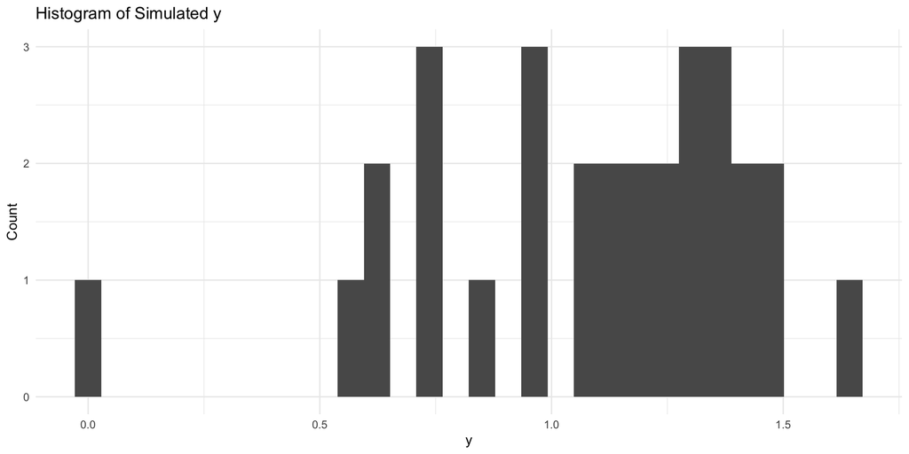

```r
df = data.frame(y)
library(ggplot2)
ggplot(df, aes(x = y)) +
  geom_histogram(bins = 30) +
  labs(title = "Histogram of Simulated y", x = "y", y = "Count") +
  theme_minimal()
```

## Example 1 (Cont’d)

If we put `n = 10000`, it is indeed the bell shape!

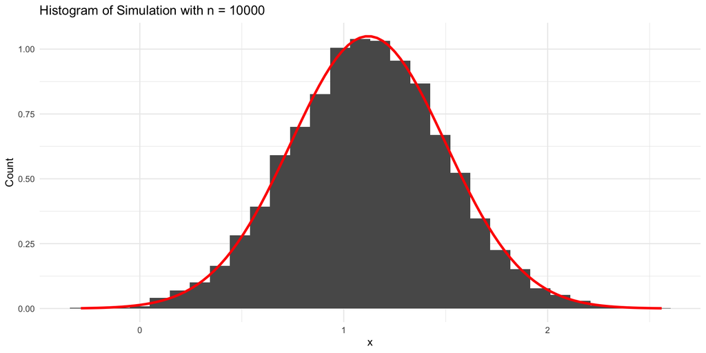

## Example 1 (Cont’d)

- Recall our BUGS syntax: `writeLines(model_code, "model.txt")`
- You don’t really need to specify `inits`

```r
# Prepare data for JAGS
jagsData <- list(
  y = y,
  N = length(y)
)

# Initial values for the model
jags_inits <- function() {
  list(mu = rnorm(1, 0, 10), sigma = runif(1, 0, 10)) # priors
}

# Parameters to monitor
jags_params <- c("mu", "sigma","tau")

# Load rjags and run the model
library(rjags)
model_1 <- jags.model(file = "model.txt", data = jagsData, inits = jags_inits, n.chains = 3)
```

## Example 1 (Cont’d)

```r
# Sample from posterior
samples <- coda.samples(model_1, variable.names = jags_params, n.iter = 2000, n.burnin = 1000)

# Convert to matrix for easier manipulation
output <- as.matrix(samples)

# Extract results
mu_samples <- output[, "mu"]
sigma_samples <- output[, "sigma"]
tau_samples <- output[,"tau"]

# Summary statistics
# posterior prediction
mean(mu_samples)
```

```
[1] 1.082505
```

```r
mean(sigma_samples)
```

```
[1] 0.364133
```

```r
mean(tau_samples)
```

```
[1] 7.969234
```

- Recall our ground truth: `mu = 1.12`, `sigma = 0.38`. What will you conclude about the result from JAGS.

## Example 1 (Cont’d) - Trace Plot

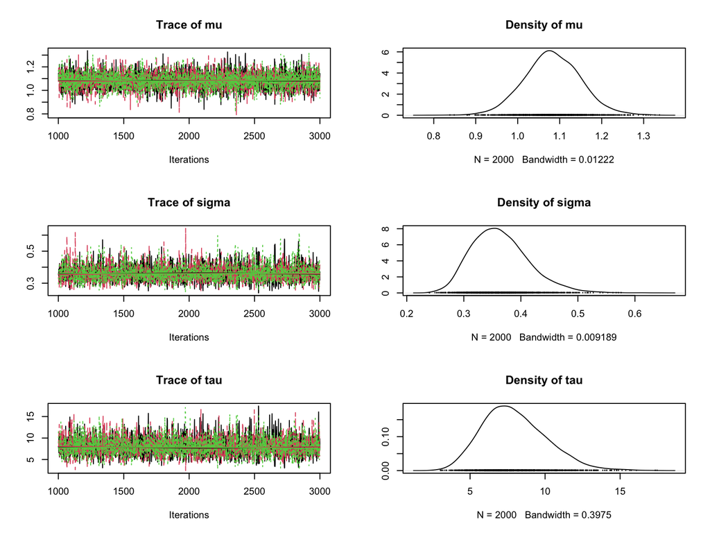

```r
# Plot MCMC chains
plot(samples)
```

## Example 1 (Cont’d) - Autocorrelation Plot & Effective Sample Size

```r
autocorr.diag(samples)
```

```
                 mu        sigma         tau
Lag 0   1.000000000  1.000000000 1.000000000
Lag 1   0.009312622  0.318260820 0.264140568
Lag 5  -0.001764873  0.015554877 0.004417441
Lag 10 -0.023571937 -0.007064481 0.001528996
Lag 50  0.011847274  0.009990329 0.006010372
```

```r
effectiveSize(samples)
```

```
      mu    sigma      tau
6000.000 3031.739 3490.870
```

```r
# autocorr.plot(samples)
```

## Example 1 (Cont’d) - Gelman-Rubin

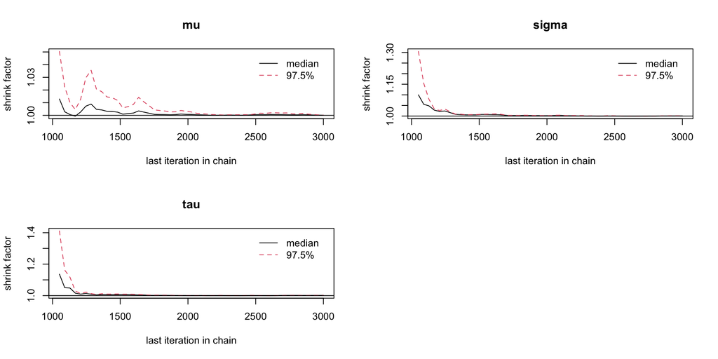

```r
#Examine convergence of the Markov chains using the Gelman-Brooks-Rubin diagnostic
gelman.plot(samples)
```

## Example 2 (Cont’d)

$$y_i=\beta_0+\beta_1 x_i+\epsilon_i \quad \epsilon_i \sim N\left(0, \sigma^2\right)$$

Priors are:

$$\begin{gathered}
\beta_0 \sim N(0,1000) \\
\beta_1 \sim N(0,1000) \\
\sigma^2 \sim \text { Inv- } \operatorname{Gamma}(0.001,0.001)
\end{gathered}$$

```r
rm(list=ls())
# Ground Truth
set.seed(425)
N <- 48
beta0_true <- 2
beta1_true <- 0.5
sigma_true <- 1
# Generate synthetic data
x <- rnorm(N, 5, 2)
y <- rnorm(N, beta0_true + beta1_true * x, sigma_true)
```

## Example 2 (Cont’d)

Recall our BUGS syntax: `writeLines(model_code_2, "model_2.txt")`

```r
# Prepare data for JAGS
jags_data <- list(
  N = N,
  x = x,
  y = y
)

# Initial values for chains
inits <- function() {
  list(beta0 = rnorm(1, 0, 1),
       beta1 = rnorm(1, 0, 1),
       sigma2 = runif(1, 0, 5))
}

# Parameters to monitor
params <- c("beta0", "beta1", "sigma2", "tau2")

# Load rjags and run the model
library(rjags)
model_2 <- jags.model("model_2.txt",
                    data = jags_data,
                    inits = inits,
                    n.chains = 3)
```

## Example 2 (Cont’d)

```r
samples_2 <- coda.samples(model_2, variable.names = params, n.iter = 3000, n.burnin = 1000)

# Convert to matrix for easier manipulation
output_2 <- as.matrix(samples_2)

# Extract results
beta0_samples <- output_2[, "beta0"]
beta1_samples <- output_2[, "beta1"]
sigma_samples_2 <- output_2[,"sigma2"]
tau_samples_2 <- output_2[,"tau2"]

# Summary statistics
# posterior prediction
mean(beta0_samples)
```

```
[1] 2.020783
```

```r
mean(beta1_samples)
```

```
[1] 0.5111791
```

```r
mean(sigma_samples_2)
```

```
[1] 0.9804739
```

```r
mean(tau_samples_2)
```

```
[1] 1.076603
```

- Recall our ground truth: `beta0_true = 2`, `beta1_true = 0.5`, `sigma_true=1`. What will you conclude about the result from JAGS.

## Example 2 (Cont’d) - Trace Plot

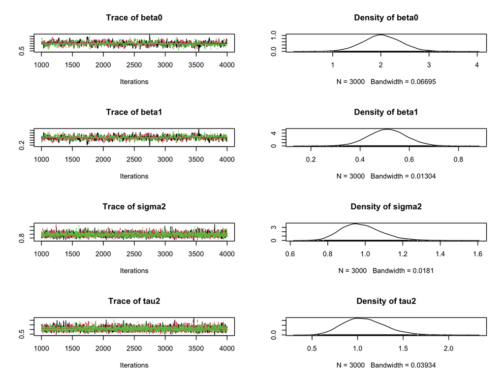

```r
# Plot MCMC chains
plot(samples_2)
```

## Example 2 (Cont’d) - Autocorrelation Plot & Effective Sample Size

```r
autocorr.diag(samples_2)
```

```
             beta0        beta1      sigma2        tau2
Lag 0   1.00000000  1.000000000  1.00000000  1.00000000
Lag 1   0.86960161  0.869262316  0.29152484  0.25753450
Lag 5   0.48095873  0.484984866  0.02353548  0.02028183
Lag 10  0.23565689  0.241176162 -0.01052395 -0.00648531
Lag 50 -0.01118447 -0.005982752 -0.01135816 -0.00418368
```

```r
effectiveSize(samples_2)
```

```
    beta0     beta1    sigma2      tau2
 640.5723  654.0244 4648.2861 5015.6441
```

```r
# autocorr.plot(samples)
```

## Example 2 (Cont’d) - Gelman-Rubin

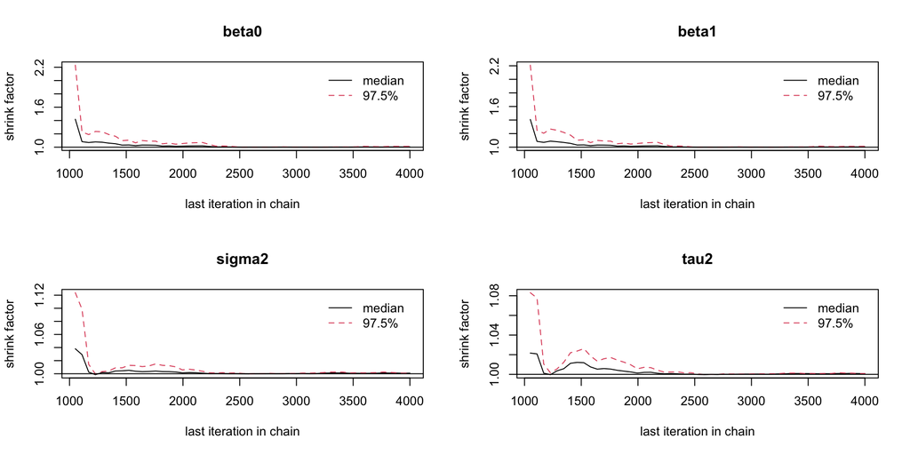

```r
#Examine convergence of the Markov chains using the Gelman-Brooks-Rubin diagnostic
gelman.plot(samples_2)
```

## Finally

[figure not shown]

## Resources

- [JAGS (official site)](https://mcmc-jags.sourceforge.io/)
- [*JAGS: A program for analysis of Bayesian graphical models using Gibbs sampling* by Martyn Plummer — University of Warwick](https://www.r-project.org/conferences/DSC-2003/Drafts/Plummer.pdf)
- [Rebecca Steorts, *Introduction to Just Another Gibbs Sampler (JAGS)* — Duke University](https://www2.stat.duke.edu/~rcs46/jags_present.pdf)
- [*An Introduction to Bayesian Reasoning and Methods* by Kevin Davis](https://peterhoff.io/book/)
- [*A First Course in Bayesian Statistical Methods* by Dr. Peter Hoff](https://peterhoff.io/book/)
- [Ritvik Kharkar](https://www.linkedin.com/in/ritvik-kharkar/)
- Original slide materials were prepared by [Dr. Scott Liang](https://www.linkedin.com/in/mliang4/) and [Enyu Li](https://www.linkedin.com/in/enyu-li-aa52a119a/).
- Updated and expanded under the supervision of [Dr. Marina Vannucci](https://marina.blogs.rice.edu/).

## Example 3: Random-Intercept Model in Action (Optional practice)

$y_{i j}=\beta_0+\theta_i+\beta_1 x_{i j}+\varepsilon_{i j}, \quad \theta_i \sim N\left(0, \tau^2\right), \quad \varepsilon_{i j} \sim N\left(0, \sigma^2\right)$

$\beta_0 \sim N(0,1000), \quad \beta_1 \sim N(0,1000)$

$\tau^2 \sim \operatorname{Inv-Gamma}(0.001,0.001), \quad \sigma^2 \sim \operatorname{Inv-Gamma}(0.001,0.001)$

```
# Model specification
model_code <-
  "
  model {
    for (i in 1:N_pig) {
      for (j in 1:N_obs) {
        y[i, j] ~ dnorm(mu[i, j], tau_eps)
        mu[i, j] <- beta0 + theta[i] + beta1 * x[i, j]
      }
      theta[i] ~ dnorm(0, tau_theta)
    }
    beta0 ~ dnorm(0, 0.001)
    beta1 ~ dnorm(0, 0.001)
    sigma ~ dunif(0, 100)
    tau_eps <- pow(sigma, -2)
    sigma_theta ~ dunif(0, 100)
    tau_theta <- pow(sigma_theta, -2)
  }
  "

# Write model to file
writeLines(model_code, "model.txt")
```

**Note**

Feel free to email me at `jk201@rice.edu` if you want to check your answer or go over the solution together.

# Thank you!

Have a great rest of your day!